# Project: Investigate a Dataset

- Introduction
- Data Wrangling
- Exploratory Data Analysis
- Conclusions

## Introduction

```python
import pandas as pd
import matplotlib.pyplot as plt
import seaborn as sns
import numpy as np
% matplotlib inline
```

```python
!pip install seaborn --upgrade
```

[output not shown]

```python
!pip install pandas --upgrade
```

[output not shown]

## Data Wrangling

### In this study we choose: income rate, population per km, average life expectancy, and suicide rate per 100k

### Unfortunately, the data for the suicde rate per 100k in the gapmineder website is missing alot of data, thus we will have to get it manualy through the total population dataset and the total suicide deaths

```python
df_income= pd.read_csv('income_per_person.csv')
df_perkm= pd.read_csv('population_density_per_square_km.csv')
df_suicide_total=pd.read_csv('suicide_total_deaths.csv')
df_lifex=pd.read_csv('life_expectancy_years.csv')
df_population_total=pd.read_csv('population_total.csv')
df_income.head()
```

|  | country | 1800 | 1801 | 1802 | 1803 | 1804 | 1805 | 1806 | 1807 | 1808 | ... | 2031 | 2032 | 2033 | 2034 | 2035 | 2036 | 2037 | 2038 | 2039 | 2040 |
| --- | --- | --- | --- | --- | --- | --- | --- | --- | --- | --- | --- | --- | --- | --- | --- | --- | --- | --- | --- | --- | --- |
| 0 | Afghanistan | 603 | 603 | 603 | 603 | 603 | 603 | 603 | 603 | 603 | ... | 2550 | 2600 | 2660 | 2710 | 2770 | 2820 | 2880 | 2940 | 3000 | 3060 |
| 1 | Albania | 667 | 667 | 667 | 667 | 667 | 668 | 668 | 668 | 668 | ... | 19400 | 19800 | 20200 | 20600 | 21000 | 21500 | 21900 | 22300 | 22800 | 23300 |
| 2 | Algeria | 715 | 716 | 717 | 718 | 719 | 720 | 721 | 722 | 723 | ... | 14300 | 14600 | 14900 | 15200 | 15500 | 15800 | 16100 | 16500 | 16800 | 17100 |
| 3 | Andorra | 1200 | 1200 | 1200 | 1200 | 1210 | 1210 | 1210 | 1210 | 1220 | ... | 73600 | 75100 | 76700 | 78300 | 79900 | 81500 | 83100 | 84800 | 86500 | 88300 |
| 4 | Angola | 618 | 620 | 623 | 626 | 628 | 631 | 634 | 637 | 640 | ... | 6110 | 6230 | 6350 | 6480 | 6610 | 6750 | 6880 | 7020 | 7170 | 7310 |

5 rows × 242 columns

```python
df_perkm.head()
```

|  | country | 1950 | 1951 | 1952 | 1953 | 1954 | 1955 | 1956 | 1957 | 1958 | ... | 2091 | 2092 | 2093 | 2094 | 2095 | 2096 | 2097 | 2098 | 2099 | 2100 |
| --- | --- | --- | --- | --- | --- | --- | --- | --- | --- | --- | --- | --- | --- | --- | --- | --- | --- | --- | --- | --- | --- |
| 0 | Afghanistan | 11.90 | 12.00 | 12.20 | 12.30 | 12.50 | 12.70 | 12.90 | 13.10 | 13.30 | ... | 117.0 | 117.0 | 117.0 | 117.0 | 116.0 | 116.0 | 116.0 | 115.0 | 115.0 | 115.0 |
| 1 | Albania | 46.10 | 47.00 | 48.00 | 49.20 | 50.50 | 51.80 | 53.30 | 54.80 | 56.30 | ... | 48.5 | 47.5 | 46.5 | 45.5 | 44.5 | 43.5 | 42.5 | 41.6 | 40.6 | 39.7 |
| 2 | Algeria | 3.73 | 3.79 | 3.86 | 3.93 | 4.01 | 4.10 | 4.20 | 4.31 | 4.41 | ... | 29.6 | 29.6 | 29.6 | 29.6 | 29.7 | 29.7 | 29.7 | 29.7 | 29.7 | 29.7 |
| 3 | Andorra | 13.20 | 14.20 | 15.40 | 16.70 | 18.20 | 19.60 | 21.20 | 22.90 | 24.70 | ... | 134.0 | 134.0 | 134.0 | 134.0 | 133.0 | 133.0 | 133.0 | 133.0 | 133.0 | 133.0 |
| 4 | Angola | 3.65 | 3.70 | 3.78 | 3.87 | 3.96 | 4.05 | 4.12 | 4.19 | 4.26 | ... | 135.0 | 136.0 | 138.0 | 140.0 | 142.0 | 144.0 | 146.0 | 147.0 | 149.0 | 151.0 |

5 rows × 152 columns

```python
df_suicide_total.head()
```

|  | country | 1990 | 1991 | 1992 | 1993 | 1994 | 1995 | 1996 | 1997 | 1998 | ... | 2007 | 2008 | 2009 | 2010 | 2011 | 2012 | 2013 | 2014 | 2015 | 2016 |
| --- | --- | --- | --- | --- | --- | --- | --- | --- | --- | --- | --- | --- | --- | --- | --- | --- | --- | --- | --- | --- | --- |
| 0 | Afghanistan | 703.00 | 754.00 | 820.00 | 894.00 | 977.00 | 1050.00 | 1100.00 | 1130.00 | 1170.00 | ... | 1680.00 | 1710.00 | 1750.00 | 1760.00 | 1810.00 | 1870.00 | 1990.00 | 2080.00 | 2170.00 | 2250.00 |
| 1 | Albania | 127.00 | 130.00 | 131.00 | 135.00 | 136.00 | 142.00 | 150.00 | 162.00 | 170.00 | ... | 204.00 | 205.00 | 201.00 | 195.00 | 191.00 | 188.00 | 186.00 | 184.00 | 183.00 | 181.00 |
| 2 | Algeria | 806.00 | 822.00 | 843.00 | 866.00 | 888.00 | 912.00 | 941.00 | 983.00 | 1020.00 | ... | 1240.00 | 1250.00 | 1270.00 | 1290.00 | 1310.00 | 1340.00 | 1370.00 | 1410.00 | 1420.00 | 1440.00 |
| 3 | Andorra | 5.45 | 5.82 | 6.18 | 6.33 | 6.36 | 6.17 | 6.04 | 6.28 | 6.24 | ... | 7.39 | 7.53 | 7.67 | 7.76 | 7.85 | 7.92 | 7.97 | 7.72 | 7.78 | 7.84 |
| 4 | Angola | 645.00 | 653.00 | 667.00 | 700.00 | 735.00 | 756.00 | 738.00 | 738.00 | 816.00 | ... | 1040.00 | 1060.00 | 1080.00 | 1100.00 | 1120.00 | 1140.00 | 1170.00 | 1200.00 | 1220.00 | 1230.00 |

5 rows × 28 columns

```python
df_lifex.head()
```

|  | country | 1800 | 1801 | 1802 | 1803 | 1804 | 1805 | 1806 | 1807 | 1808 | ... | 2091 | 2092 | 2093 | 2094 | 2095 | 2096 | 2097 | 2098 | 2099 | 2100 |
| --- | --- | --- | --- | --- | --- | --- | --- | --- | --- | --- | --- | --- | --- | --- | --- | --- | --- | --- | --- | --- | --- |
| 0 | Afghanistan | 28.2 | 28.2 | 28.2 | 28.2 | 28.2 | 28.2 | 28.1 | 28.1 | 28.1 | ... | 76.5 | 76.6 | 76.7 | 76.9 | 77.0 | 77.1 | 77.3 | 77.4 | 77.5 | 77.7 |
| 1 | Albania | 35.4 | 35.4 | 35.4 | 35.4 | 35.4 | 35.4 | 35.4 | 35.4 | 35.4 | ... | 87.4 | 87.5 | 87.6 | 87.7 | 87.8 | 87.9 | 88.0 | 88.1 | 88.2 | 88.3 |
| 2 | Algeria | 28.8 | 28.8 | 28.8 | 28.8 | 28.8 | 28.8 | 28.8 | 28.8 | 28.8 | ... | 88.3 | 88.4 | 88.5 | 88.6 | 88.7 | 88.8 | 88.9 | 89.0 | 89.1 | 89.2 |
| 3 | Andorra | NaN | NaN | NaN | NaN | NaN | NaN | NaN | NaN | NaN | ... | NaN | NaN | NaN | NaN | NaN | NaN | NaN | NaN | NaN | NaN |
| 4 | Angola | 27.0 | 27.0 | 27.0 | 27.0 | 27.0 | 27.0 | 27.0 | 27.0 | 27.0 | ... | 78.7 | 78.9 | 79.0 | 79.1 | 79.3 | 79.4 | 79.5 | 79.7 | 79.8 | 79.9 |

5 rows × 302 columns

```python
df_population_total.head()
```

|  | country | 1800 | 1801 | 1802 | 1803 | 1804 | 1805 | 1806 | 1807 | 1808 | ... | 2091 | 2092 | 2093 | 2094 | 2095 | 2096 | 2097 | 2098 | 2099 | 2100 |
| --- | --- | --- | --- | --- | --- | --- | --- | --- | --- | --- | --- | --- | --- | --- | --- | --- | --- | --- | --- | --- | --- |
| 0 | Afghanistan | 3280000 | 3280000 | 3280000 | 3280000 | 3280000 | 3280000 | 3280000 | 3280000 | 3280000 | ... | 76600000 | 76400000 | 76300000 | 76100000 | 76000000 | 75800000 | 75600000 | 75400000 | 75200000 | 74900000 |
| 1 | Albania | 400000 | 402000 | 404000 | 405000 | 407000 | 409000 | 411000 | 413000 | 414000 | ... | 1330000 | 1300000 | 1270000 | 1250000 | 1220000 | 1190000 | 1170000 | 1140000 | 1110000 | 1090000 |
| 2 | Algeria | 2500000 | 2510000 | 2520000 | 2530000 | 2540000 | 2550000 | 2560000 | 2560000 | 2570000 | ... | 70400000 | 70500000 | 70500000 | 70600000 | 70700000 | 70700000 | 70700000 | 70700000 | 70700000 | 70700000 |
| 3 | Andorra | 2650 | 2650 | 2650 | 2650 | 2650 | 2650 | 2650 | 2650 | 2650 | ... | 63000 | 62900 | 62900 | 62800 | 62700 | 62700 | 62600 | 62500 | 62500 | 62400 |
| 4 | Angola | 1570000 | 1570000 | 1570000 | 1570000 | 1570000 | 1570000 | 1570000 | 1570000 | 1570000 | ... | 168000000 | 170000000 | 172000000 | 175000000 | 177000000 | 179000000 | 182000000 | 184000000 | 186000000 | 188000000 |

5 rows × 302 columns

### *It does seem that our lowest max year is in the total sucide rates -which is 2016- and the highest min year is also in the total suicide rates -which is 1990-, thus we will be trimming our data to start at 1990 and end at 2016

```python
years = np.arange(1800,1990,dtype=int)
for i in years:
    i=i.astype(str)
    df_income.drop(i,axis=1,inplace=True)
    df_lifex.drop(i,axis=1,inplace=True)
    df_population_total.drop(i,axis=1,inplace=True)
```

```python
years= np.arange(1950,1990,dtype=int)
for i in years:
    i=i.astype(str)
    df_perkm.drop(i,axis=1,inplace=True)
```

```python
years=np.arange(2017,2101,dtype=int)
for i in years:
    i=i.astype(str)
    df_lifex.drop(i,axis=1,inplace=True)
    df_population_total.drop(i,axis=1,inplace=True)
    df_perkm.drop(i,axis=1,inplace=True)
```

```python
years=np.arange(2017,2041,dtype=int)
for i in years:
    i=i.astype(str)
    df_income.drop(i,axis=1,inplace=True)
```

```python
df_income.columns,df_lifex.columns,df_population_total.columns,df_perkm.columns
```

```
(Index(['country', '1990', '1991', '1992', '1993', '1994', '1995', '1996',
        '1997', '1998', '1999', '2000', '2001', '2002', '2003', '2004', '2005',
        '2006', '2007', '2008', '2009', '2010', '2011', '2012', '2013', '2014',
        '2015', '2016'],
       dtype='object'),
 Index(['country', '1990', '1991', '1992', '1993', '1994', '1995', '1996',
        '1997', '1998', '1999', '2000', '2001', '2002', '2003', '2004', '2005',
        '2006', '2007', '2008', '2009', '2010', '2011', '2012', '2013', '2014',
        '2015', '2016'],
       dtype='object'),
 Index(['country', '1990', '1991', '1992', '1993', '1994', '1995', '1996',
        '1997', '1998', '1999', '2000', '2001', '2002', '2003', '2004', '2005',
        '2006', '2007', '2008', '2009', '2010', '2011', '2012', '2013', '2014',
        '2015', '2016'],
       dtype='object'),
 Index(['country', '1990', '1991', '1992', '1993', '1994', '1995', '1996',
        '1997', '1998', '1999', '2000', '2001', '2002', '2003', '2004', '2005',
        '2006', '2007', '2008', '2009', '2010', '2011', '2012', '2013', '2014',
        '2015', '2016'],
       dtype='object'))
```

### Now we need to reshape the data set so that it follows this shape: country, year, income ,etc...

```python
df_income=df_income.melt('country')
df_lifex=df_lifex.melt('country')
df_population_total=df_population_total.melt('country')
df_perkm=df_perkm.melt('country')
df_suicide_total=df_suicide_total.melt('country')
```

```python
df_income.rename(columns={'variable':'year', 'value':'income'},inplace=True)
df_lifex.rename(columns={'variable':'year', 'value':'life_expectancy'},inplace=True)
df_population_total.rename(columns={'variable':'year', 'value':'population_total'},inplace=True)
df_perkm.rename(columns={'variable':'year', 'value':'population_per_km'},inplace=True)
df_suicide_total.rename(columns={'variable':'year', 'value':'suicide_total'},inplace=True)
```

```python
df_income.head()
```

|  | country | year | income |
| --- | --- | --- | --- |
| 0 | Afghanistan | 1990 | 1860 |
| 1 | Albania | 1990 | 4460 |
| 2 | Algeria | 1990 | 10300 |
| 3 | Andorra | 1990 | 28400 |
| 4 | Angola | 1990 | 4760 |

```python
df_income.info()
```

```
<class 'pandas.core.frame.DataFrame'>
RangeIndex: 5211 entries, 0 to 5210
Data columns (total 3 columns):
country    5211 non-null object
year       5211 non-null object
income     5211 non-null int64
dtypes: int64(1), object(2)
memory usage: 122.2+ KB
```

```python
type(df_income['year'][0])
```

```
str
```

### since the data is from the same source, we do not need to check data types for each data set. One problem we notice is that the year column is string so we will change it to intiger

```python
df_income['year']= df_income['year'].astype(int)
df_lifex['year']= df_lifex['year'].astype(int)
df_population_total['year']= df_population_total['year'].astype(int)
df_perkm['year']= df_perkm['year'].astype(int)
df_suicide_total['year']= df_suicide_total['year'].astype(int)
```

```python
type(df_income['year'][0])
```

```
numpy.int64
```

### Now we will check the data set for any proplems

```python
df_income.duplicated().sum()
```

```
0
```

```python
df_income.isnull().sum()
```

```
country    0
year       0
income     0
dtype: int64
```

```python
df_lifex.duplicated().sum()
```

```
0
```

> while working with the data set, I used the inplace function so the data saves its changes and this cell was run again during the revison of the code. it used to show missing value for the lifex data

```python
df_lifex.isnull().sum()
```

```
country            0
year               0
life_expectancy    0
dtype: int64
```

```python
df_population_total.isnull().sum()
```

```
country             0
year                0
population_total    0
dtype: int64
```

```python
df_perkm.isnull().sum()
```

```
country              0
year                 0
population_per_km    0
dtype: int64
```

```python
df_suicide_total.isnull().sum()
```

```
country          0
year             0
suicide_total    0
dtype: int64
```

### It seems like the values for some countries have null values so we will fill those null values with the closeset year , to make it easier we will first arrange the data set according to the country and the year

```python
df_lifex=df_lifex.sort_values(by =['country', 'year'])
```

```python
df_lifex.fillna(method='ffill',inplace=True)
```

```python
df_lifex.isnull().sum()
```

```
country            0
year               0
life_expectancy    0
dtype: int64
```

```python
df_income.shape
```

```
(5211, 3)
```

```python
df_lifex.shape
```

```
(5049, 3)
```

```python
df_suicide_total.shape
```

```
(5049, 3)
```

```python
df_perkm.shape
```

```
(5265, 3)
```

```python
df_population_total.shape
```

```
(5265, 3)
```

```python
#found the code for this part here :https://www.geeksforgeeks.org/find-elements-present-first-array-not-second/
def findMissing(a, b, n, m):
    dof=[]
    for i in range(n):
        for j in range(m):
            if (a[i] == b[j]):
                break

        if (j == m - 1):
            dof.append(a[i])
    return(dof)

a=df_income['country'].unique()
b=df_lifex['country'].unique()
l_of_a = len(a)
l_of_b = len(b)
income_life=findMissing(a, b, l_of_a, l_of_b)
```

```python
a=df_income['country'].unique()
b=df_suicide_total['country'].unique()
l_of_a = len(a)
l_of_b = len(b)
income_suicide=findMissing(a, b, l_of_a, l_of_b)
```

```python
a=df_income['country'].unique()
b=df_perkm['country'].unique()
l_of_a = len(a)
l_of_b = len(b)
income_perkm=findMissing(a, b, l_of_a, l_of_b)
```

```python
a=df_income['country'].unique()
b=df_population_total['country'].unique()
l_of_a = len(a)
l_of_b = len(b)
income_population=findMissing(a, b, l_of_a, l_of_b)
```

```python
a=df_lifex['country'].unique()
b=df_income['country'].unique()
l_of_a = len(a)
l_of_b = len(b)
life_income=findMissing(a, b, l_of_a, l_of_b)
```

```python
a=df_perkm['country'].unique()
b=df_income['country'].unique()
l_of_a = len(a)
l_of_b = len(b)
perkm_income=findMissing(a, b, l_of_a, l_of_b)
```

```python
perkm_income
```

```
['Holy See', 'Liechtenstein', 'Zimbabwe']
```

```python
life_income
```

```
['Zimbabwe']
```

```python
income_life==income_suicide
```

```
True
```

```python
income_perkm==income_population
```

```
True
```

```python
income_life==income_perkm
```

```
False
```

```python
income_perkm
```

```
['Zimbabwe']
```

```python
df_perkm['country'].unique()==df_population_total['country'].unique()
```

```
array([ True,  True,  True,  True,  True,  True,  True,  True,  True,
        True,  True,  True,  True,  True,  True,  True,  True,  True,
        True,  True,  True,  True,  True,  True,  True,  True,  True,
        True,  True,  True,  True,  True,  True,  True,  True,  True,
        True,  True,  True,  True,  True,  True,  True,  True,  True,
        True,  True,  True,  True,  True,  True,  True,  True,  True,
        True,  True,  True,  True,  True,  True,  True,  True,  True,
        True,  True,  True,  True,  True,  True,  True,  True,  True,
        True,  True,  True,  True,  True,  True,  True,  True,  True,
        True,  True,  True,  True,  True,  True,  True,  True,  True,
        True,  True,  True,  True,  True,  True,  True,  True,  True,
        True,  True,  True,  True,  True,  True,  True,  True,  True,
        True,  True,  True,  True,  True,  True,  True,  True,  True,
        True,  True,  True,  True,  True,  True,  True,  True,  True,
        True,  True,  True,  True,  True,  True,  True,  True,  True,
        True,  True,  True,  True,  True,  True,  True,  True,  True,
        True,  True,  True,  True,  True,  True,  True,  True,  True,
        True,  True,  True,  True,  True,  True,  True,  True,  True,
        True,  True,  True,  True,  True,  True,  True,  True,  True,
        True,  True,  True,  True,  True,  True,  True,  True,  True,
        True,  True,  True,  True,  True,  True,  True,  True,  True,
        True,  True,  True,  True,  True,  True], dtype=bool)
```

```python
income_life
```

```
['Monaco',
 'Nauru',
 'Palau',
 'San Marino',
 'St. Kitts and Nevis',
 'Tuvalu',
 'Zimbabwe']
```

### After checking, there are some countries present in some data and not in others, thus we will drop those countries

```python
df_income.set_index('country',inplace=True)
df_perkm.set_index('country',inplace=True)
df_population_total.set_index('country',inplace=True)
df_lifex.set_index('country',inplace=True)
df_suicide_total.set_index('country',inplace=True)
```

```python
for i in income_life:
    df_income.drop(i,axis=0,inplace=True)
```

```python
for i in income_life:
    df_perkm.drop(i,axis=0,inplace=True)
    df_population_total.drop(i,axis=0,inplace=True)
```

```python
countries_drop=['Holy See', 'Liechtenstein']
for i in countries_drop:
    df_population_total.drop(i,axis=0,inplace=True)
```

```python
for i in countries_drop:
    df_perkm.drop(i,axis=0,inplace=True)
```

```python
df_suicide_total.drop('Zimbabwe',axis=0,inplace=True)
```

```python
for i in life_income:
    df_lifex.drop(i,axis=0,inplace=True)
```

```python
df_income.query('country== "Monaco"')
```

|  | year | income |
| --- | --- | --- |
| country |  |  |

```python
df_income['country']=df_income.index
```

```python
df_suicide_total['country']=df_suicide_total.index
df_perkm['country']=df_perkm.index
df_population_total['country']=df_population_total.index
df_lifex['country']=df_lifex.index
```

```python
df_income['country'].unique()==df_suicide_total['country'].unique()
```

```
array([ True,  True,  True,  True,  True,  True,  True,  True,  True,
        True,  True,  True,  True,  True,  True,  True,  True,  True,
        True,  True,  True,  True,  True,  True,  True,  True,  True,
        True,  True,  True,  True,  True,  True,  True,  True,  True,
        True,  True,  True,  True,  True,  True,  True,  True,  True,
        True,  True,  True,  True,  True,  True,  True,  True,  True,
        True,  True,  True,  True,  True,  True,  True,  True,  True,
        True,  True,  True,  True,  True,  True,  True,  True,  True,
        True,  True,  True,  True,  True,  True,  True,  True,  True,
        True,  True,  True,  True,  True,  True,  True,  True,  True,
        True,  True,  True,  True,  True,  True,  True,  True,  True,
        True,  True,  True,  True,  True,  True,  True,  True,  True,
        True,  True,  True,  True,  True,  True,  True,  True,  True,
        True,  True,  True,  True,  True,  True,  True,  True,  True,
        True,  True,  True,  True,  True,  True,  True,  True,  True,
        True,  True,  True,  True,  True,  True,  True,  True,  True,
        True,  True,  True,  True,  True,  True,  True,  True,  True,
        True,  True,  True,  True,  True,  True,  True,  True,  True,
        True,  True,  True,  True,  True,  True,  True,  True,  True,
        True,  True,  True,  True,  True,  True,  True,  True,  True,
        True,  True,  True,  True,  True,  True], dtype=bool)
```

```python
df_population_total['country'].unique()==df_income['country'].unique()
```

```
array([ True,  True,  True,  True,  True,  True,  True,  True,  True,
        True,  True,  True,  True,  True,  True,  True,  True,  True,
        True,  True,  True,  True,  True,  True,  True,  True,  True,
        True,  True,  True,  True,  True,  True,  True,  True,  True,
        True,  True,  True,  True,  True,  True,  True,  True,  True,
        True,  True,  True,  True,  True,  True,  True,  True,  True,
        True,  True,  True,  True,  True,  True,  True,  True,  True,
        True,  True,  True,  True,  True,  True,  True,  True,  True,
        True,  True,  True,  True,  True,  True,  True,  True,  True,
        True,  True,  True,  True,  True,  True,  True,  True,  True,
        True,  True,  True,  True,  True,  True,  True,  True,  True,
        True,  True,  True,  True,  True,  True,  True,  True,  True,
        True,  True,  True,  True,  True,  True,  True,  True,  True,
        True,  True,  True,  True,  True,  True,  True,  True,  True,
        True,  True,  True,  True,  True,  True,  True,  True,  True,
        True,  True,  True,  True,  True,  True,  True,  True,  True,
        True,  True,  True,  True,  True,  True,  True,  True,  True,
        True,  True,  True,  True,  True,  True,  True,  True,  True,
        True,  True,  True,  True,  True,  True,  True,  True,  True,
        True,  True,  True,  True,  True,  True,  True,  True,  True,
        True,  True,  True,  True,  True,  True], dtype=bool)
```

```python
df_income['country'].unique()==df_lifex['country'].unique()
```

```
array([ True,  True,  True,  True,  True,  True,  True,  True,  True,
        True,  True,  True,  True,  True,  True,  True,  True,  True,
        True,  True,  True,  True,  True,  True,  True,  True,  True,
        True,  True,  True,  True,  True,  True,  True,  True,  True,
        True,  True,  True,  True,  True,  True,  True,  True,  True,
        True,  True,  True,  True,  True,  True,  True,  True,  True,
        True,  True,  True,  True,  True,  True,  True,  True,  True,
        True,  True,  True,  True,  True,  True,  True,  True,  True,
        True,  True,  True,  True,  True,  True,  True,  True,  True,
        True,  True,  True,  True,  True,  True,  True,  True,  True,
        True,  True,  True,  True,  True,  True,  True,  True,  True,
        True,  True,  True,  True,  True,  True,  True,  True,  True,
        True,  True,  True,  True,  True,  True,  True,  True,  True,
        True,  True,  True,  True,  True,  True,  True,  True,  True,
        True,  True,  True,  True,  True,  True,  True,  True,  True,
        True,  True,  True,  True,  True,  True,  True,  True,  True,
        True,  True,  True,  True,  True,  True,  True,  True,  True,
        True,  True,  True,  True,  True,  True,  True,  True,  True,
        True,  True,  True,  True,  True,  True,  True,  True,  True,
        True,  True,  True,  True,  True,  True,  True,  True,  True,
        True,  True,  True,  True,  True,  True], dtype=bool)
```

```python
df_income['country'].unique()==df_perkm['country'].unique()
```

```
array([ True,  True,  True,  True,  True,  True,  True,  True,  True,
        True,  True,  True,  True,  True,  True,  True,  True,  True,
        True,  True,  True,  True,  True,  True,  True,  True,  True,
        True,  True,  True,  True,  True,  True,  True,  True,  True,
        True,  True,  True,  True,  True,  True,  True,  True,  True,
        True,  True,  True,  True,  True,  True,  True,  True,  True,
        True,  True,  True,  True,  True,  True,  True,  True,  True,
        True,  True,  True,  True,  True,  True,  True,  True,  True,
        True,  True,  True,  True,  True,  True,  True,  True,  True,
        True,  True,  True,  True,  True,  True,  True,  True,  True,
        True,  True,  True,  True,  True,  True,  True,  True,  True,
        True,  True,  True,  True,  True,  True,  True,  True,  True,
        True,  True,  True,  True,  True,  True,  True,  True,  True,
        True,  True,  True,  True,  True,  True,  True,  True,  True,
        True,  True,  True,  True,  True,  True,  True,  True,  True,
        True,  True,  True,  True,  True,  True,  True,  True,  True,
        True,  True,  True,  True,  True,  True,  True,  True,  True,
        True,  True,  True,  True,  True,  True,  True,  True,  True,
        True,  True,  True,  True,  True,  True,  True,  True,  True,
        True,  True,  True,  True,  True,  True,  True,  True,  True,
        True,  True,  True,  True,  True,  True], dtype=bool)
```

```python
df_income.shape
```

```
(5022, 3)
```

```python
df_lifex.shape
```

```
(5022, 3)
```

```python
df_population_total.shape
```

```
(5022, 3)
```

```python
df_suicide_total.shape
```

```
(5022, 3)
```

```python
df_perkm.shape
```

```
(5022, 3)
```

### Now the data is the same size and has the same countries

### Now we will save the data after we cleaned it

```python
df_income.to_csv('income_per_person_clean.csv',index=False)
```

```python
df_lifex.to_csv('life_expectancy_clean.csv',index=False)
df_perkm.to_csv('population_perkm_clean.csv',index=False)
df_population_total.to_csv('population_total_clean.csv',index=False)
df_suicide_total.to_csv('suicide_total_clean.csv',index=False)
```

### And load it again

```python
df_income= pd.read_csv('income_per_person_clean.csv')
df_perkm= pd.read_csv('population_perkm_clean.csv')
df_suicide_total=pd.read_csv('suicide_total_clean.csv')
df_lifex=pd.read_csv('life_expectancy_clean.csv')
df_population_total=pd.read_csv('population_total_clean.csv')
```

### Now we we need to get the suicide rate per 100k in order to get an accurate representation of the data:

```python
df_suicide_total.head()
```

|  | year | suicide_total | country |
| --- | --- | --- | --- |
| 0 | 1990 | 703.00 | Afghanistan |
| 1 | 1990 | 127.00 | Albania |
| 2 | 1990 | 806.00 | Algeria |
| 3 | 1990 | 5.45 | Andorra |
| 4 | 1990 | 645.00 | Angola |

```python
df_population_total.head()
```

|  | year | population_total | country |
| --- | --- | --- | --- |
| 0 | 1990 | 12400000 | Afghanistan |
| 1 | 1990 | 3290000 | Albania |
| 2 | 1990 | 25800000 | Algeria |
| 3 | 1990 | 54500 | Andorra |
| 4 | 1990 | 11800000 | Angola |

### Since the data is arranged accodring to the country and the year, we do not need specify any key :

```python
data=(df_suicide_total['suicide_total']/df_population_total['population_total'])*100000
df_suicide_per100k=pd.DataFrame(data,columns=['suicide_per_100k'])
```

```python
df_suicide_per100k.head()
```

|  | suicide_per_100k |
| --- | --- |
| 0 | 5.669355 |
| 1 | 3.860182 |
| 2 | 3.124031 |
| 3 | 10.000000 |
| 4 | 5.466102 |

### Now we will merge the data:

```python
data=df_income['country']
```

```python
df_combined=pd.DataFrame(data)
```

```python
df_combined.insert(1,"year",df_perkm['year'])
```

```python
df_combined.insert(2,"population_per_km",df_perkm['population_per_km'])
```

```python
df_combined.insert(3,"life_expectancy",df_lifex['life_expectancy'])
```

```python
df_combined.insert(4,"suicide_per_100k",df_suicide_per100k['suicide_per_100k'])
```

```python
df_combined.insert(2,"income",df_income['income'])
```

```python
df_combined.head()
```

|  | country | year | income | population_per_km | life_expectancy | suicide_per_100k |
| --- | --- | --- | --- | --- | --- | --- |
| 0 | Afghanistan | 1990 | 1860 | 19.0 | 52.6 | 5.669355 |
| 1 | Albania | 1990 | 4460 | 120.0 | 52.4 | 3.860182 |
| 2 | Algeria | 1990 | 10300 | 10.8 | 52.9 | 3.124031 |
| 3 | Andorra | 1990 | 28400 | 116.0 | 53.1 | 10.000000 |
| 4 | Angola | 1990 | 4760 | 9.5 | 52.7 | 5.466102 |

### Now one finale check on the data

```python
df_combined.isnull().sum()
```

```
country              0
year                 0
income               0
population_per_km    0
life_expectancy      0
suicide_per_100k     0
dtype: int64
```

```python
df_combined.duplicated().sum()
```

```
0
```

```python
df_combined.shape
```

```
(5022, 6)
```

```python
df_combined.info()
```

```
<class 'pandas.core.frame.DataFrame'>
Index: 5022 entries, 0 to 5021
Data columns (total 6 columns):
country              5022 non-null object
year                 5022 non-null int64
income               5022 non-null int64
population_per_km    5022 non-null float64
life_expectancy      5022 non-null float64
suicide_per_100k     5022 non-null float64
dtypes: float64(3), int64(2), object(1)
memory usage: 434.6+ KB
```

```python
df_combined['year']= df_combined['year'].astype(int)
```

```python
df_combined.head()
```

|  | country | year | income | population_per_km | life_expectancy | suicide_per_100k |
| --- | --- | --- | --- | --- | --- | --- |
| 0 | Afghanistan | 1990 | 1860 | 19.0 | 52.6 | 5.669355 |
| 1 | Albania | 1990 | 4460 | 120.0 | 52.4 | 3.860182 |
| 2 | Algeria | 1990 | 10300 | 10.8 | 52.9 | 3.124031 |
| 3 | Andorra | 1990 | 28400 | 116.0 | 53.1 | 10.000000 |
| 4 | Angola | 1990 | 4760 | 9.5 | 52.7 | 5.466102 |

```python
df_combined['country'].nunique()
```

```
186
```

## Finaly, the data is clean and merged

```python
df_combined.to_csv('gapminder_data_cleaned&merged.csv',index=False)
```

```python
df=pd.read_csv('gapminder_data_cleaned&merged.csv')
```

### Now we will creat 2 new columns in order to classify each country according to its continent and income to help in the visualization

```python
Africa = ('Algeria','Angola','Benin','Botswana','Burkina','Burundi','Cameroon','Cape Verde','Central African Republic','Chad','Comoros','Congo','Congo, Democratic Republic of','Djibouti','Egypt','Equatorial Guinea','Eritrea','Ethiopia','Gabon','Gambia','Ghana','Guinea','Guinea-Bissau','Ivory Coast','Kenya','Lesotho','Liberia','Libya','Madagascar','Malawi','Mali','Mauritania','Mauritius','Morocco','Mozambique','Namibia','Niger','Nigeria','Rwanda','Sao Tome and Principe','Senegal','Seychelles','Sierra Leone','Somalia','South Africa','South Sudan','Sudan','Swaziland','Tanzania','Togo','Tunisia','Uganda','Zambia','Zimbabwe','Burkina Faso','Congo, Dem. Rep.','Congo, Rep.','Cote d\'Ivoire','Eswatini')
Asia = ('South Korea','Palestine','Timor-Leste','Afghanistan','Bahrain','Bangladesh','Bhutan','Brunei','Burma (Myanmar)','Cambodia','China','East Timor','India','Indonesia','Iran','Iraq','Israel','Japan','Jordan','Kazakhstan','Korea, North','Korea, South','Kuwait','Kyrgyzstan','Laos','Lebanon','Malaysia','Maldives','Mongolia','Nepal','Oman','Pakistan','Philippines','Qatar','Russia','Saudi Arabia','Singapore','Sri Lanka','Syria','Tajikistan','Thailand','Turkey','Turkmenistan','United Arab Emirates','Uzbekistan','Vietnam','Yemen','Russia','Kyrgyz Republic','Lao','Myanmar','North Korea')
Europe = ('Slovak Republic','North Macedonia','Albania','Andorra','Armenia','Austria','Azerbaijan','Belarus','Belgium','Bosnia and Herzegovina','Bulgaria','Croatia','Cyprus','Czech Republic','Denmark','Estonia','Finland','France','Georgia','Germany','Greece','Hungary','Iceland','Ireland','Italy','Latvia','Liechtenstein','Lithuania','Luxembourg','Macedonia','Malta','Moldova','Monaco','Montenegro','Netherlands','Norway','Poland','Portugal','Romania','San Marino','Serbia','Slovakia','Slovenia','Spain','Sweden','Switzerland','Ukraine','United Kingdom','Vatican City')
North_America = ('St. Vincent and the Grenadines','St. Lucia','Antigua and Barbuda','Bahamas','Barbados','Belize','Canada','Costa Rica','Cuba','Dominica','Dominican Republic','El Salvador','Grenada','Guatemala','Haiti','Honduras','Jamaica','Mexico','Nicaragua','Panama','Saint Kitts and Nevis','Saint Lucia','Saint Vincent and the Grenadines','Trinidad and Tobago','United States')
South_America = ('Argentina','Bolivia','Brazil','Chile','Colombia','Ecuador','Guyana','Paraguay','Peru','Suriname','Uruguay','Venezuela')
Australia_Oceania = ('Australia','Fiji','Kiribati','Marshall Islands','Micronesia','Nauru','New Zealand','Palau','Papua New Guinea','Samoa','Solomon Islands','Tonga','Tuvalu','Vanuatu','Micronesia, Fed. Sts.')
```

```python
def continent(c):
    if c in Africa:
        return 'Africa'
    elif c in Asia:
        return 'Asia'
    elif c in Europe:
        return 'Europe'
    elif c in North_America:
        return 'North_America'
    elif c in South_America:
        return 'South_America'
    elif c in Australia_Oceania:
        return 'Australia_Oceania'
```

```python
df['continent'] = df['country'].apply(continent)
```

```python
df.head()
```

|  | country | year | income | population_per_km | life_expectancy | suicide_per_100k | continent |
| --- | --- | --- | --- | --- | --- | --- | --- |
| 0 | Afghanistan | 1990 | 1860 | 19.0 | 52.6 | 5.669355 | Asia |
| 1 | Albania | 1990 | 4460 | 120.0 | 52.4 | 3.860182 | Europe |
| 2 | Algeria | 1990 | 10300 | 10.8 | 52.9 | 3.124031 | Africa |
| 3 | Andorra | 1990 | 28400 | 116.0 | 53.1 | 10.000000 | Europe |
| 4 | Angola | 1990 | 4760 | 9.5 | 52.7 | 5.466102 | Africa |

```python
df['continent'].isnull().sum()
```

```
0
```

```python
df['income'].describe()
```

```
count      5022.000000
mean      14615.179809
std       17944.563949
min         361.000000
25%        2790.000000
50%        7880.000000
75%       19375.000000
max      124000.000000
Name: income, dtype: float64
```

```python
def income_per(c):
    if c < 2790:
        return 'below 25%'
    elif c < 7880 and c >= 2790:
        return 'below 50%'
    elif c < 19375 and c >= 7880:
        return 'below 75%'
    elif c >= 19375:
        return 'above 75%'
```

```python
df['income_percent'] = df['income'].apply(income_per)
```

```python
df.head()
```

|  | country | year | income | population_per_km | life_expectancy | suicide_per_100k | continent | income_percent |
| --- | --- | --- | --- | --- | --- | --- | --- | --- |
| 0 | Afghanistan | 1990 | 1860 | 19.0 | 52.6 | 5.669355 | Asia | below 25% |
| 1 | Albania | 1990 | 4460 | 120.0 | 52.4 | 3.860182 | Europe | below 50% |
| 2 | Algeria | 1990 | 10300 | 10.8 | 52.9 | 3.124031 | Africa | below 75% |
| 3 | Andorra | 1990 | 28400 | 116.0 | 53.1 | 10.000000 | Europe | above 75% |
| 4 | Angola | 1990 | 4760 | 9.5 | 52.7 | 5.466102 | Africa | below 50% |

```python
df['income_percent'].isnull().sum()
```

```
0
```

### Finaly, the data is complete

```python
df.to_csv('gapminder_done.csv',index=False)
```

## Exploratory Data Analysis

## Q1:

### Which continent has the highest income rate and did that change over the years

```python
df=pd.read_csv('gapminder_done.csv')
```

```python
df.head()
```

|  | country | year | income | population_per_km | life_expectancy | suicide_per_100k | continent | income_percent |
| --- | --- | --- | --- | --- | --- | --- | --- | --- |
| 0 | Afghanistan | 1990 | 1860 | 19.0 | 52.6 | 5.669355 | Asia | below 25% |
| 1 | Albania | 1990 | 4460 | 120.0 | 52.4 | 3.860182 | Europe | below 50% |
| 2 | Algeria | 1990 | 10300 | 10.8 | 52.9 | 3.124031 | Africa | below 75% |
| 3 | Andorra | 1990 | 28400 | 116.0 | 53.1 | 10.000000 | Europe | above 75% |
| 4 | Angola | 1990 | 4760 | 9.5 | 52.7 | 5.466102 | Africa | below 50% |

```python
df_area=df.groupby(['continent','year'],as_index=False).mean()
```

```python
df_area.head()
```

|  | continent | year | income | population_per_km | life_expectancy | suicide_per_100k |
| --- | --- | --- | --- | --- | --- | --- |
| 0 | Africa | 1990 | 3645.018868 | 58.220566 | 72.139623 | 6.648232 |
| 1 | Africa | 1991 | 3704.075472 | 59.251887 | 73.318868 | 6.681754 |
| 2 | Africa | 1992 | 3659.867925 | 60.174340 | 69.692453 | 6.730773 |
| 3 | Africa | 1993 | 3599.471698 | 61.015472 | 66.267925 | 6.765713 |
| 4 | Africa | 1994 | 3575.943396 | 61.975472 | 62.111321 | 6.868799 |

```python
df_area['continent'].unique()
```

```
array(['Africa', 'Asia', 'Australia_Oceania', 'Europe', 'North_America',
       'South_America'], dtype=object)
```

```python
df_africa=df_area.query('continent == "Africa"')
df_asia=df_area.query('continent == "Asia"')
df_australia_oceania=df_area.query('continent == "Australia_Oceania"')
df_europe=df_area.query('continent == "Europe"')
df_north_america=df_area.query('continent == "North_America"')
df_south_america=df_area.query('continent == "South_America"')
```

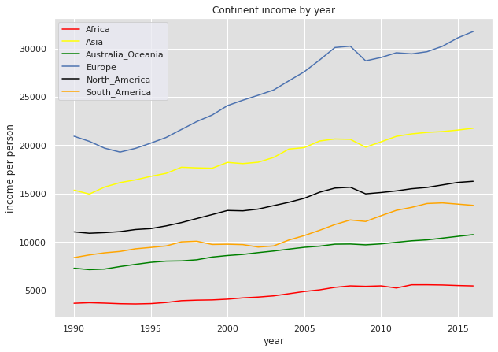

```python
plt.figure(figsize=(10, 7))
ax=plt.axes()
ax.set(facecolor = "#e0e0e0")
plt.plot(df_africa['year'],df_africa['income'],color='red',label="Africa")
plt.plot(df_asia['year'],df_asia['income'],color='yellow',label="Asia")
plt.plot(df_australia_oceania['year'],df_australia_oceania['income'],color='green',label="Australia_Oceania")
plt.plot(df_europe['year'],df_europe['income'],color='b',label="Europe")
plt.plot(df_north_america['year'],df_north_america['income'],color='black',label="North_America")
plt.plot(df_south_america['year'],df_south_america['income'],color='orange',label="South_America")
plt.xlabel('year')
plt.ylabel('income per person')
plt.title('Continent income by year')
plt.legend();
```

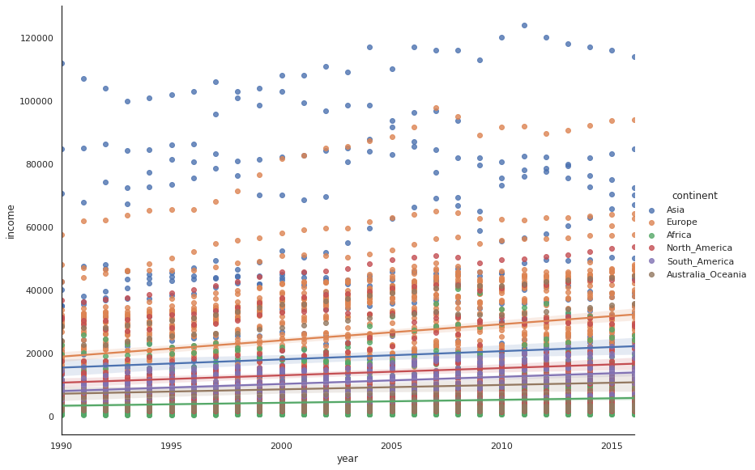

```python
sns.set(style="white")
sns.lmplot(x="year",
            y="income",
            hue="continent",
            data=df,height=8, aspect=11/8);
```

### It apears that the highest income continent is Europe followd by Asia, North America, South America, Australia/Oceania, and lastly Africa.

### But by looking at the countries, Asia seems to have the highest income country followed by Europe and North America

### The order of the continant has not been changed since 1990 but all of them have been increasing in the income rate with an exception of a few years

## Q2:

### Is there a relation between the income rate and the suicide rate

```python
df_income_per=df.groupby(['income_percent','year'],as_index=False).mean()
```

```python
df_income_per.head()
```

|  | income_percent | year | income | population_per_km | life_expectancy | suicide_per_100k |
| --- | --- | --- | --- | --- | --- | --- |
| 0 | above 75% | 1990 | 34969.230769 | 220.410256 | 70.328205 | 13.834745 |
| 1 | above 75% | 1991 | 35128.947368 | 227.345000 | 73.684211 | 13.606027 |
| 2 | above 75% | 1992 | 36872.222222 | 244.710000 | 70.527778 | 13.081355 |
| 3 | above 75% | 1993 | 37352.777778 | 250.155833 | 66.769444 | 12.929966 |
| 4 | above 75% | 1994 | 37802.702703 | 249.043243 | 63.445946 | 12.708645 |

```python
df_income_per['income_percent'].unique()
```

```
array(['above 75%', 'below 25%', 'below 50%', 'below 75%'], dtype=object)
```

```python
df_below25=df_income_per.query('income_percent == "below 25%"')
df_below50=df_income_per.query('income_percent == "below 50%"')
df_below75=df_income_per.query('income_percent == "below 75%"')
df_above75=df_income_per.query('income_percent == "above 75%"')
```

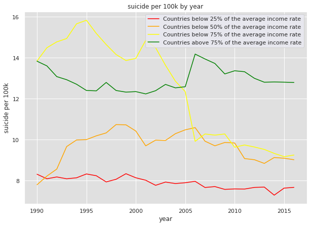

```python
plt.figure(figsize=(10, 7))
ax=plt.axes()
ax.set(facecolor = "#e0e0e0")
plt.plot(df_below25['year'],df_below25['suicide_per_100k'],color='red',label="Countries below 25% of the average income rate")
plt.plot(df_below50['year'],df_below50['suicide_per_100k'],color='orange',label="Countries below 50% of the average income rate")
plt.plot(df_below75['year'],df_below75['suicide_per_100k'],color='yellow',label="Countries below 75% of the average income rate")
plt.plot(df_above75['year'],df_above75['suicide_per_100k'],color='green',label="Countries above 75% of the average income rate")
plt.xlabel('year')
plt.ylabel('suicide per 100k')
plt.title('suicide per 100k by year')
plt.legend();
```

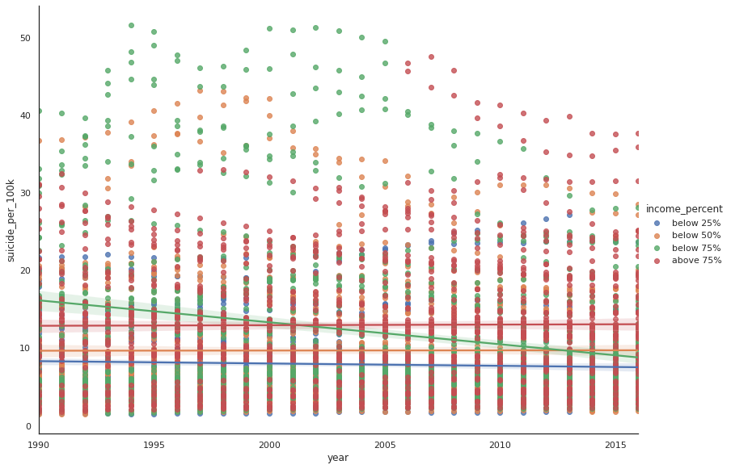

```python
sns.set(style="white")
sns.lmplot(x="year",
            y="suicide_per_100k",
            hue="income_percent",
            data=df,height=8, aspect=11/8);
```

### We can see a pattern of the lowest income countries having the lowest suicide rate -lower than 25% of the average income rate- followed by the lower 50% average income rate, but in case of the Countries above 75% of the average income rate and Countries below 75% of the average income rate it isn't quite obvious.

### Also it's important to point out that Countries below 75% of the average income rate had lower suicide rate than countries below 50 % of the average income rate 2 times, once starting in about 2006 and once in about 2010

### In order to get more insight on our data, we will get the country with the maximum average income for each income percent

##### The reason for not using the code: df.groupby(['income_percent','county'],as_index=False).mean().max()

###### is that it kept duplicating the data and didn't work probably

```python
dg=df.groupby(['country'],as_index=False).mean()
```

### The order is the same so we can just add the collumn

```python
dg['income_percent']=df['income_percent']
```

```python
dg
```

|  | country | year | income | population_per_km | life_expectancy | suicide_per_100k | income_percent |
| --- | --- | --- | --- | --- | --- | --- | --- |
| 0 | Afghanistan | 2003.0 | 1260.222222 | 36.525926 | 67.425926 | 6.005422 | below 25% |
| 1 | Albania | 2003.0 | 6952.962963 | 112.037037 | 67.837037 | 5.739982 | below 50% |
| 2 | Algeria | 2003.0 | 11417.407407 | 13.696296 | 68.170370 | 3.452258 | below 75% |
| 3 | Andorra | 2003.0 | 35655.555556 | 153.148148 | 68.070370 | 9.520139 | above 75% |
| 4 | Angola | 2003.0 | 4999.629630 | 15.230741 | 68.429630 | 4.964205 | below 50% |
| ... | ... | ... | ... | ... | ... | ... | ... |
| 181 | Vanuatu | 2003.0 | 2715.185185 | 16.762963 | 66.944444 | 15.452262 | below 25% |
| 182 | Venezuela | 2003.0 | 15755.555556 | 28.770370 | 67.255556 | 8.547891 | below 75% |
| 183 | Vietnam | 2003.0 | 3280.370370 | 264.000000 | 67.285185 | 8.832265 | below 25% |
| 184 | Yemen | 2003.0 | 3849.629630 | 36.444444 | 67.503704 | 4.532794 | below 50% |
| 185 | Zambia | 2003.0 | 2662.222222 | 15.566667 | 67.766667 | 8.009850 | below 25% |

186 rows × 7 columns

```python
dg.groupby(['income_percent'],as_index=False)['suicide_per_100k'].max()
```

|  | income_percent | suicide_per_100k |
| --- | --- | --- |
| 0 | above 75% | 42.909595 |
| 1 | below 25% | 22.584408 |
| 2 | below 50% | 32.647601 |
| 3 | below 75% | 43.152541 |

```python
dg.query('suicide_per_100k >42.8 and income_percent =="above 75%"')
```

|  | country | year | income | population_per_km | life_expectancy | suicide_per_100k | income_percent |
| --- | --- | --- | --- | --- | --- | --- | --- |
| 138 | Russia | 2003.0 | 18859.259259 | 8.892593 | 68.425926 | 42.909595 | above 75% |

```python
dg.query('suicide_per_100k >22.5 and income_percent =="below 25%"')
```

|  | country | year | income | population_per_km | life_expectancy | suicide_per_100k | income_percent |
| --- | --- | --- | --- | --- | --- | --- | --- |
| 88 | Kiribati | 2003.0 | 1897.407407 | 111.97037 | 69.444444 | 22.584408 | below 25% |

```python
dg.query('suicide_per_100k >43 and income_percent =="below 75%"')
```

|  | country | year | income | population_per_km | life_expectancy | suicide_per_100k | income_percent |
| --- | --- | --- | --- | --- | --- | --- | --- |
| 97 | Lithuania | 2003.0 | 17237.777778 | 53.688889 | 69.151852 | 43.152541 | below 75% |

```python
dg.query('suicide_per_100k >32.6 and income_percent =="below 50%"')
```

|  | country | year | income | population_per_km | life_expectancy | suicide_per_100k | income_percent |
| --- | --- | --- | --- | --- | --- | --- | --- |
| 156 | Sri Lanka | 2003.0 | 6653.703704 | 307.222222 | 67.818519 | 32.647601 | below 50% |

### Now we have our top countries we can start plotting them

```python
df_top=df.query('country=="Russia" or country=="Lithuania" or country=="Sri Lanka" or country=="Kiribati"')
```

```python
df_top
```

|  | country | year | income | population_per_km | life_expectancy | suicide_per_100k | continent | income_percent |
| --- | --- | --- | --- | --- | --- | --- | --- | --- |
| 88 | Kiribati | 1990 | 1940 | 89.40 | 80.3 | 21.685083 | Australia_Oceania | below 25% |
| 97 | Lithuania | 1990 | 15600 | 59.00 | 82.0 | 31.891892 | Europe | below 75% |
| 138 | Russia | 1990 | 20600 | 9.01 | 74.3 | 31.081081 | Asia | above 75% |
| 156 | Sri Lanka | 1990 | 3610 | 276.00 | 76.7 | 36.763006 | Asia | below 50% |
| 274 | Kiribati | 1991 | 1910 | 91.00 | 63.5 | 21.709634 | Australia_Oceania | below 25% |
| ... | ... | ... | ... | ... | ... | ... | ... | ... |
| 4806 | Sri Lanka | 2015 | 11100 | 333.00 | 75.6 | 23.636364 | Asia | below 75% |
| 4924 | Kiribati | 2016 | 2050 | 139.00 | 74.0 | 23.628319 | Australia_Oceania | below 25% |
| 4933 | Lithuania | 2016 | 28000 | 46.10 | 74.8 | 37.716263 | Europe | above 75% |
| 4974 | Russia | 2016 | 24400 | 8.87 | 61.2 | 35.862069 | Asia | above 75% |
| 4992 | Sri Lanka | 2016 | 11400 | 335.00 | 69.0 | 23.714286 | Asia | below 75% |

108 rows × 8 columns

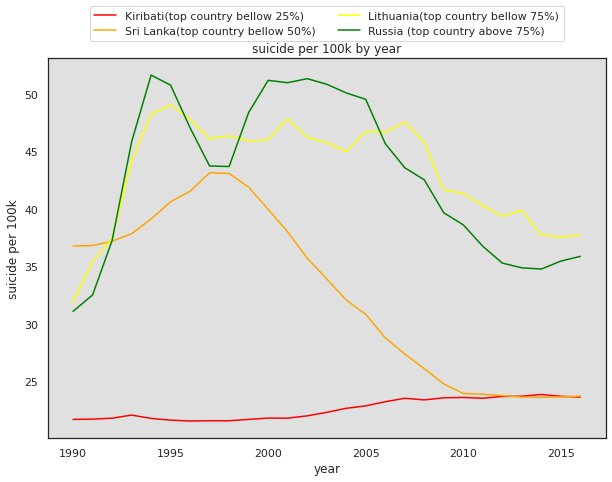

```python
plt.figure(figsize=(10, 7))
ax=plt.axes()
ax.set(facecolor = "#e0e0e0")
plt.plot(df_top.query('country == "Kiribati"')['year'],df_top.query('country == "Kiribati"')['suicide_per_100k'],color='red',label="Kiribati(top country bellow 25%)")
plt.plot(df_top.query('country == "Sri Lanka"')['year'],df_top.query('country == "Sri Lanka"')['suicide_per_100k'],color='orange',label="Sri Lanka(top country bellow 50%)")
plt.plot(df_top.query('country == "Lithuania"')['year'],df_top.query('country == "Lithuania"')['suicide_per_100k'],color='yellow',label="Lithuania(top country bellow 75%)")
plt.plot(df_top.query('country == "Russia"')['year'],df_top.query('country == "Russia"')['suicide_per_100k'],color='green',label="Russia (top country above 75%)")
plt.xlabel('year')
plt.ylabel('suicide per 100k')
plt.title('suicide per 100k by year')
plt.legend(loc="upper center", bbox_to_anchor=(0.5, 1.15), ncol=2);
```

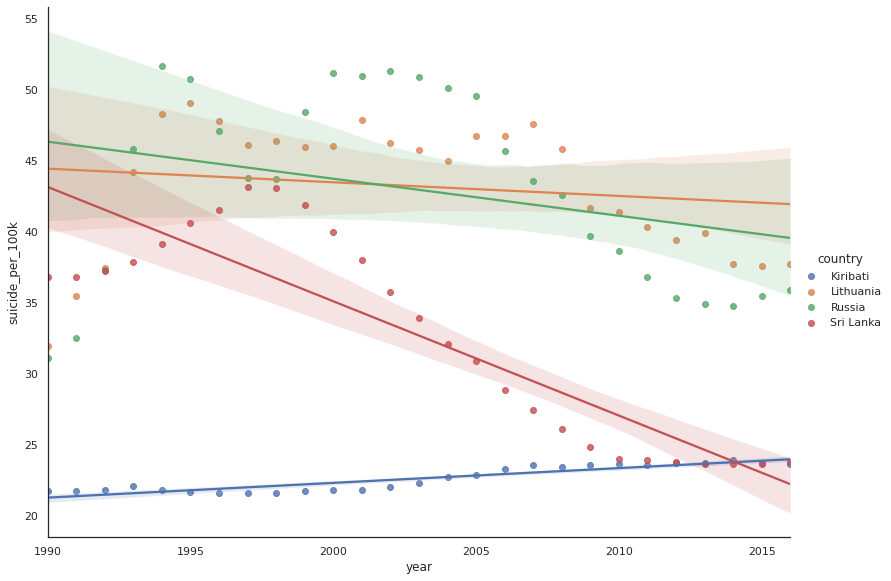

```python
sns.set(style="white")
sns.lmplot(x="year",
            y="suicide_per_100k",
            hue="country",
            data=df_top,height=8, aspect=11/8);
```

### In this case we have the 1st above 75% -Russia- and the 1st bellow 75% -Lithuania- countries having the highest numbers followed by the 1st below 50% -Sri Lanka- and lastly, the 1st bellow 25% country -Kiribati-.

### The graph seems to follow the last conclusion of the higher income countries having higher suicide rate

## Q3:

### Does the population per km affect the average income rate:

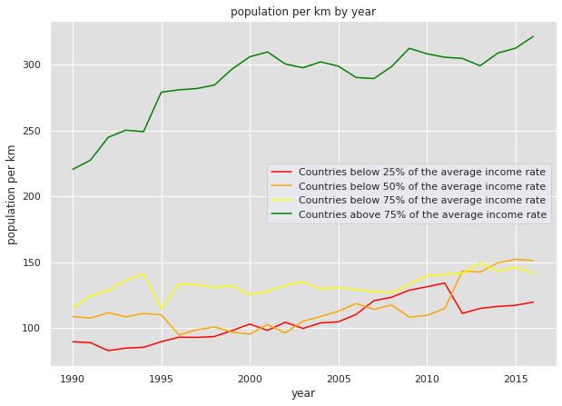

```python
plt.figure(figsize=(10, 7))
ax=plt.axes()
ax.set(facecolor = "#e0e0e0")
plt.plot(df_below25['year'],df_below25['population_per_km'],color='red',label="Countries below 25% of the average income rate")
plt.plot(df_below50['year'],df_below50['population_per_km'],color='orange',label="Countries below 50% of the average income rate")
plt.plot(df_below75['year'],df_below75['population_per_km'],color='yellow',label="Countries below 75% of the average income rate")
plt.plot(df_above75['year'],df_above75['population_per_km'],color='green',label="Countries above 75% of the average income rate")
plt.xlabel('year')
plt.ylabel('population per km')
plt.title('population per km by year')
plt.legend();
```

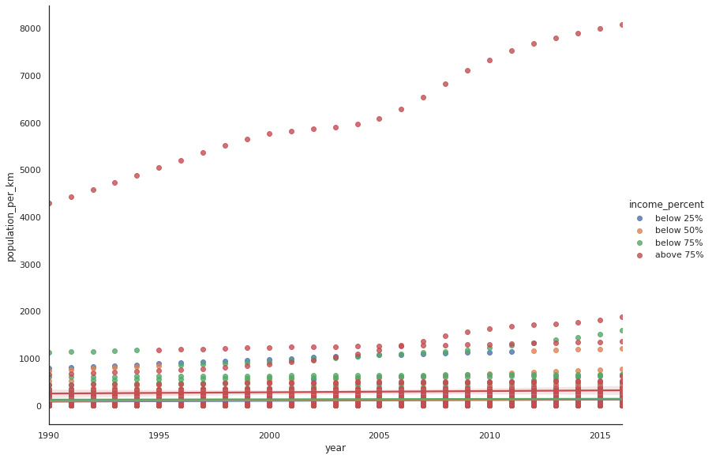

```python
sns.set(style="white")
sns.lmplot(x="year",
            y="population_per_km",
            hue="income_percent",
            data=df,height=8, aspect=11/8)
```

### There does seem to be an outlier in the data

```python
df.sort_values('population_per_km', ascending=False).iloc[0:30]
```

|  | country | year | income | population_per_km | life_expectancy | suicide_per_100k | continent | income_percent |
| --- | --- | --- | --- | --- | --- | --- | --- | --- |
| 4983 | Singapore | 2016 | 84700 | 8080.0 | 65.9 | 7.044248 | Asia | above 75% |
| 4797 | Singapore | 2015 | 83300 | 7990.0 | 79.8 | 6.958855 | Asia | above 75% |
| 4611 | Singapore | 2014 | 82000 | 7890.0 | 74.4 | 7.124774 | Asia | above 75% |
| 4425 | Singapore | 2013 | 79900 | 7790.0 | 65.0 | 7.284404 | Asia | above 75% |
| 4239 | Singapore | 2012 | 77500 | 7670.0 | 70.5 | 7.411546 | Asia | above 75% |
| 4053 | Singapore | 2011 | 76000 | 7520.0 | 60.6 | 7.433460 | Asia | above 75% |
| 3867 | Singapore | 2010 | 73100 | 7330.0 | 59.2 | 7.660819 | Asia | above 75% |
| 3681 | Singapore | 2009 | 64900 | 7100.0 | 73.5 | 8.048290 | Asia | above 75% |
| 3495 | Singapore | 2008 | 66800 | 6820.0 | 77.8 | 8.347280 | Asia | above 75% |
| 3309 | Singapore | 2007 | 69200 | 6540.0 | 57.3 | 8.799127 | Asia | above 75% |
| 3123 | Singapore | 2006 | 66200 | 6290.0 | 57.6 | 9.477273 | Asia | above 75% |
| 2937 | Singapore | 2005 | 62600 | 6090.0 | 75.5 | 9.601874 | Asia | above 75% |
| 2751 | Singapore | 2004 | 59700 | 5970.0 | 74.6 | 9.904306 | Asia | above 75% |
| 2565 | Singapore | 2003 | 55100 | 5900.0 | 49.0 | 10.169492 | Asia | above 75% |
| 2379 | Singapore | 2002 | 51900 | 5860.0 | 58.6 | 10.195122 | Asia | above 75% |
| 2193 | Singapore | 2001 | 50400 | 5820.0 | 77.9 | 10.073529 | Asia | above 75% |
| 2007 | Singapore | 2000 | 52400 | 5760.0 | 71.0 | 10.272953 | Asia | above 75% |
| 1821 | Singapore | 1999 | 48900 | 5650.0 | 74.2 | 10.303797 | Asia | above 75% |
| 1635 | Singapore | 1998 | 46600 | 5520.0 | 80.4 | 10.544041 | Asia | above 75% |
| 1449 | Singapore | 1997 | 49300 | 5360.0 | 61.6 | 10.800000 | Asia | above 75% |
| 1263 | Singapore | 1996 | 47000 | 5200.0 | 79.8 | 11.043956 | Asia | above 75% |
| 1077 | Singapore | 1995 | 45600 | 5040.0 | 61.8 | 11.643059 | Asia | above 75% |
| 891 | Singapore | 1994 | 43800 | 4880.0 | 53.4 | 11.871345 | Asia | above 75% |
| 705 | Singapore | 1993 | 40700 | 4720.0 | 50.6 | 12.114804 | Asia | above 75% |
| 519 | Singapore | 1992 | 37500 | 4570.0 | 63.9 | 12.843750 | Asia | above 75% |
| 333 | Singapore | 1991 | 36200 | 4430.0 | 72.4 | 13.580645 | Asia | above 75% |
| 147 | Singapore | 1990 | 34900 | 4300.0 | 75.2 | 14.617940 | Asia | above 75% |
| 4848 | Bahrain | 2016 | 43700 | 1880.0 | 75.5 | 6.713287 | Asia | above 75% |
| 4662 | Bahrain | 2015 | 43900 | 1810.0 | 77.7 | 6.824818 | Asia | above 75% |
| 4476 | Bahrain | 2014 | 43800 | 1760.0 | 61.8 | 6.791045 | Asia | above 75% |

### It's quite clear that singapore is an outlier in our data set, thus we will drop it to get an accurate representaion

```python
df_drop_out=df[df.country!='Singapore']
```

```python
df_drop_out.query('country == "Singapore"')
```

|  | country | year | income | population_per_km | life_expectancy | suicide_per_100k | continent | income_percent |
| --- | --- | --- | --- | --- | --- | --- | --- | --- |

```python
df_income_perv2=df_drop_out.groupby(['income_percent','year'],as_index=False).mean()
```

```python
df_below25v2=df_income_perv2.query('income_percent == "below 25%"')
df_below50v2=df_income_perv2.query('income_percent == "below 50%"')
df_below75v2=df_income_perv2.query('income_percent == "below 75%"')
df_above75v2=df_income_perv2.query('income_percent == "above 75%"')
```

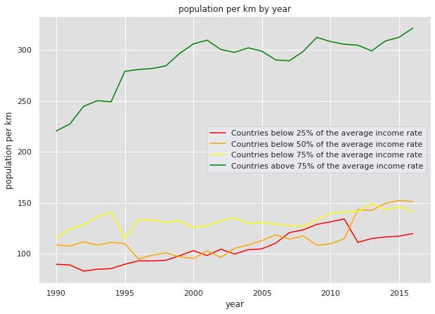

```python
plt.figure(figsize=(10, 7))
ax=plt.axes()
ax.set(facecolor = "#e0e0e0")
plt.plot(df_below25v2['year'],df_below25['population_per_km'],color='red',label="Countries below 25% of the average income rate")
plt.plot(df_below50v2['year'],df_below50['population_per_km'],color='orange',label="Countries below 50% of the average income rate")
plt.plot(df_below75v2['year'],df_below75['population_per_km'],color='yellow',label="Countries below 75% of the average income rate")
plt.plot(df_above75v2['year'],df_above75['population_per_km'],color='green',label="Countries above 75% of the average income rate")
plt.xlabel('year')
plt.ylabel('population per km')
plt.title('population per km by year')
plt.legend();
```

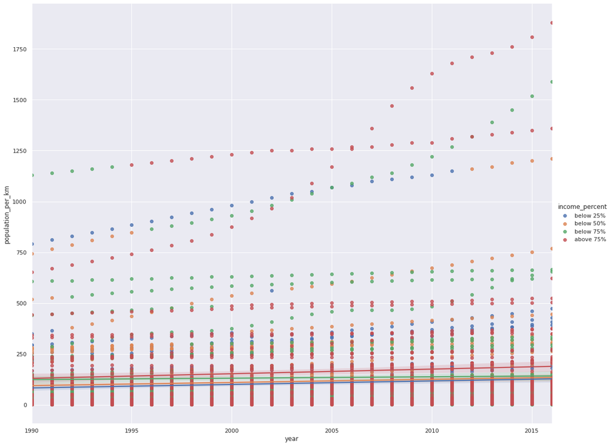

```python
sns.set(style="darkgrid")
sns.lmplot(x="year",
            y="population_per_km",
            hue="income_percent",
            data=df_drop_out,height=12, aspect=15/12);
```

### From the line plot, it apears that the higher income countries tend to have higher population per km. However, the scatter plot shows that only a number of countries have populatoin per km that high. Still, the margin is wide enough to conclude that higher income countries tend to have a higher population per km. Although the relation is not strong

## Q4:

### Do countries with higher income rate have higher life expectancy

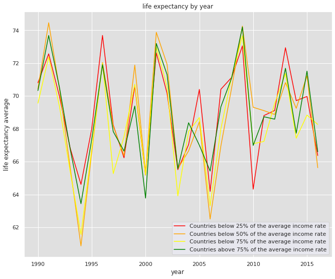

```python
plt.figure(figsize=(11, 9))
ax=plt.axes()
ax.set(facecolor = "#e0e0e0")
plt.plot(df_below25['year'],df_below25['life_expectancy'],color='red',label="Countries below 25% of the average income rate")
plt.plot(df_below50['year'],df_below50['life_expectancy'],color='orange',label="Countries below 50% of the average income rate")
plt.plot(df_below75['year'],df_below75['life_expectancy'],color='yellow',label="Countries below 75% of the average income rate")
plt.plot(df_above75['year'],df_above75['life_expectancy'],color='green',label="Countries above 75% of the average income rate")
plt.xlabel('year')
plt.ylabel('life expectancy average')
plt.title('life expectancy by year')
plt.legend();
```

### No relation can be seen from this graph, maybe looking at the denesy distribution would help better

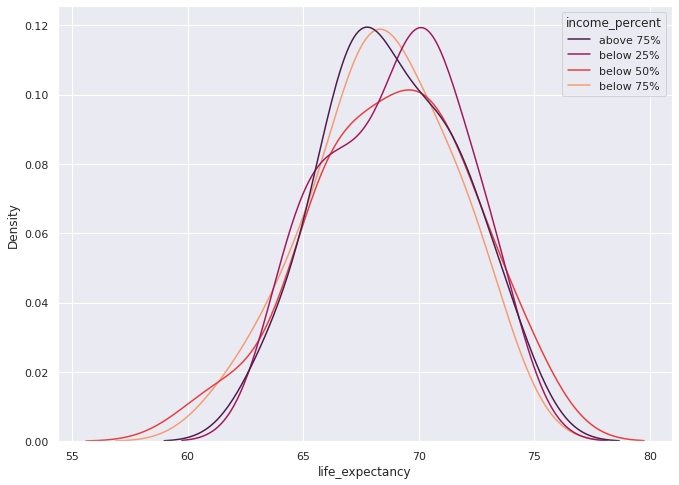

```python
sns.set(rc={'figure.figsize':(11,8)})

sns.kdeplot(data=df_income_per,x='life_expectancy',hue='income_percent', common_norm=False, palette="rocket",
   alpha=.5)
```

```python
df_income_per.groupby('income_percent').mean()
```

| income_percent | year | income | population_per_km | life_expectancy | suicide_per_100k |
| --- | --- | --- | --- | --- | --- |
| above 75% | 2003 | 39477.060083 | 288.099364 | 68.854577 | 12.935111 |
| below 25% | 2003 | 1640.850275 | 105.153753 | 68.984691 | 7.899993 |
| below 50% | 2003 | 4901.560865 | 114.438375 | 68.782800 | 9.670752 |
| below 75% | 2003 | 12269.970579 | 132.912783 | 68.358783 | 12.465729 |

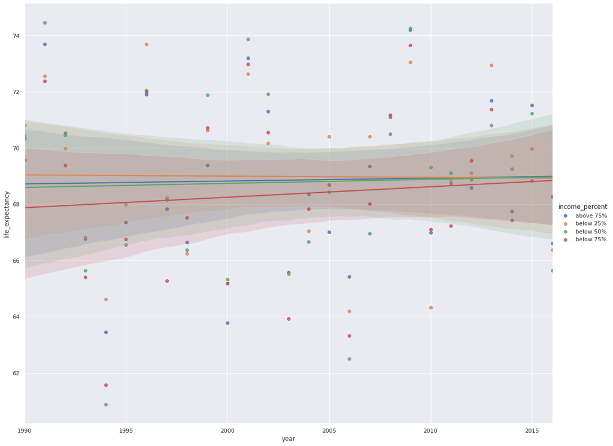

```python
sns.set(style="darkgrid")
sns.lmplot(x="year",
            y="life_expectancy",
            hue="income_percent",
            data=df_income_per,height=12, aspect=15/12);
```

### Still they all seem to be very similar in numbers

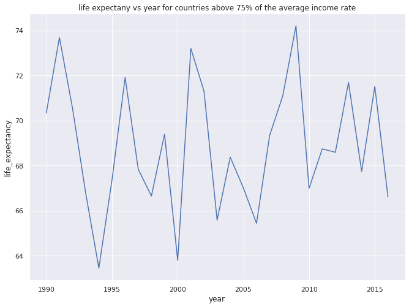

```python
sns.lineplot(data=df_above75, x="year", y="life_expectancy").set_title('life expectany vs year for countries above 75% of the average income rate');
```

### Looking at only one of the groups - countries above 75% of the average income rate- ,it apears that the result varies depending on the year and that there is no standard number that the group rotates around

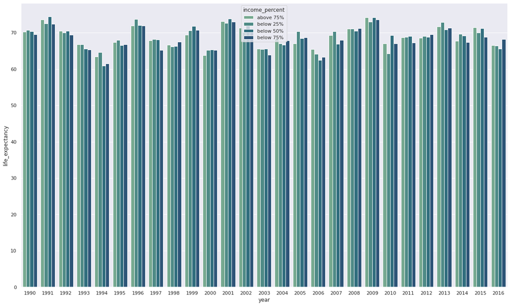

```python
sns.set(rc={'figure.figsize':(20,12)})
ax = sns.barplot(x="year", y="life_expectancy", data=df_income_per,hue='income_percent',
                 palette="crest")
```

### It apears that no relation can be seen between countries with higher income rate and life expectancy and by looking at the last bar plot, we can see that all the groups follow world wide change in the average life expectancy in the same years

### There is also certain years that the average life expectacy decreased world wide regardless of the income rate, which raises a new question, do certain continent have higher life expectancy

## Q5:

### Do certain continent have higher life expectancy:

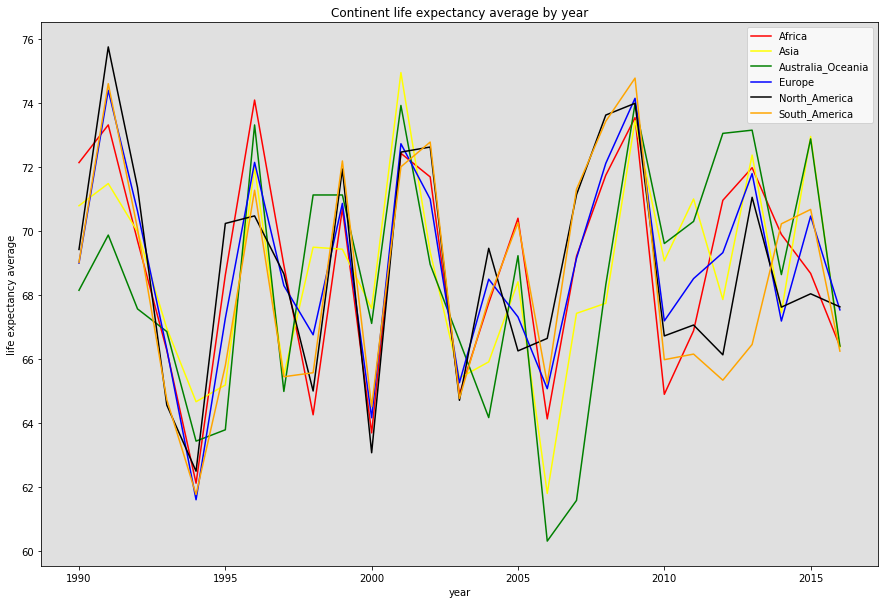

```python
plt.figure(figsize=(15, 10))
ax=plt.axes()
ax.set(facecolor = "#e0e0e0")
plt.plot(df_africa['year'],df_africa['life_expectancy'],color='red',label="Africa")
plt.plot(df_asia['year'],df_asia['life_expectancy'],color='yellow',label="Asia")
plt.plot(df_australia_oceania['year'],df_australia_oceania['life_expectancy'],color='green',label="Australia_Oceania")
plt.plot(df_europe['year'],df_europe['life_expectancy'],color='b',label="Europe")
plt.plot(df_north_america['year'],df_north_america['life_expectancy'],color='black',label="North_America")
plt.plot(df_south_america['year'],df_south_america['life_expectancy'],color='orange',label="South_America")
plt.xlabel('year')
plt.ylabel('life expectancy average')
plt.title('Continent life expectancy average by year')
plt.legend();
```

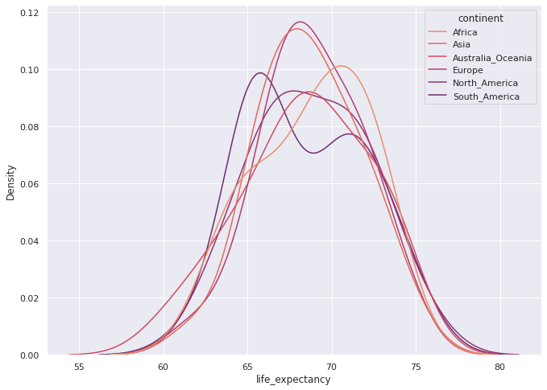

```python
sns.set(rc={'figure.figsize':(11,8)})

sns.kdeplot(data=df_area,x='life_expectancy',hue='continent', common_norm=False, palette="flare",
   alpha=.5);
```

```python
df_area.groupby('continent').mean()
```

| continent | year | income | population_per_km | life_expectancy | suicide_per_100k |
| --- | --- | --- | --- | --- | --- |
| Africa | 2003 | 4567.104123 | 76.618064 | 68.862152 | 7.017076 |
| Asia | 2003 | 18810.400823 | 332.844831 | 68.686584 | 10.079682 |
| Australia_Oceania | 2003 | 8950.909091 | 78.993401 | 68.457576 | 14.486654 |
| Europe | 2003 | 25579.000861 | 139.997459 | 68.839707 | 16.715809 |
| North_America | 2003 | 13658.265993 | 165.198754 | 68.818519 | 7.178783 |
| South_America | 2003 | 10921.666667 | 20.450463 | 68.460494 | 10.969366 |

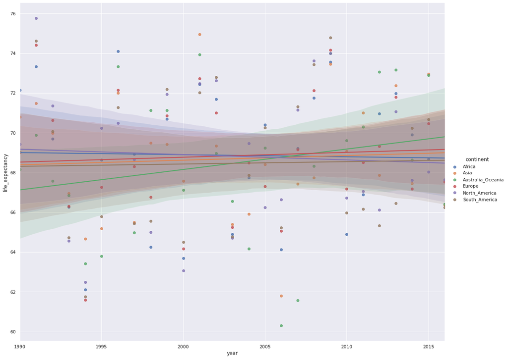

```python
sns.set(style="darkgrid")
sns.lmplot(x="year",
            y="life_expectancy",
            hue="continent",
            data=df_area,height=12, aspect=15/12);
```

### The numbers seem to be very similar in all continents

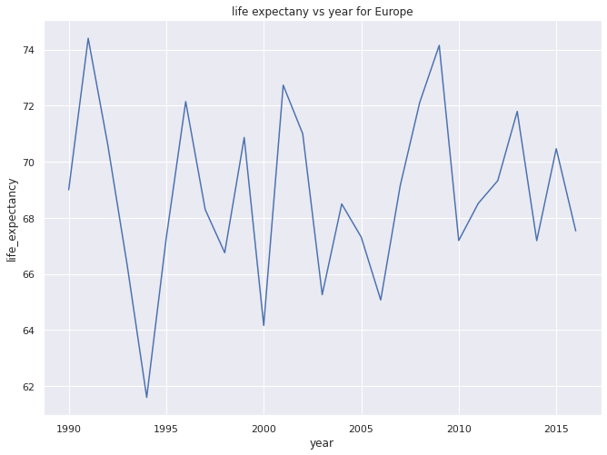

```python
sns.lineplot(data=df_area.query('continent =="Europe"'), x="year", y="life_expectancy").set_title('life expectany vs year for Europe');
```

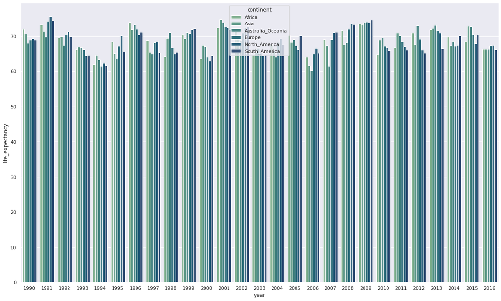

```python
sns.set(rc={'figure.figsize':(20,12)})
ax = sns.barplot(x="year", y="life_expectancy", data=df_area,hue='continent',
                 palette="crest")
```

## Conclusions

### We can conclude that:

### - The highest income continent is Europe followd by Asia, North America, South America, Australia/Oceania, and lastly Africa and the highest income coutnry is asian

### -the lowest income countries have the lowest suicide rate -lower than 25% of the average income rate- followed by the lower 50% average income rate, but in case of the Countries above 75% of the average income rate and Countries below 75% of the average income rate it isn't quite obvious. Of course, This does not mean that higher income rate is directly correlated to higher suicide rate but it's an indication that these countries have some problems that needs to be fixed

### -the higher income countries tend to have higher population per km, although the relation is not strong

### -There is no colleration between higher income rate and average life expectany

### -There is also no colleration continent and average life expectany

# limitations:

### The data that has been used was provided by gapminder and may have some inaccuracies.

### The results shown do not mean that one correletion is the result of another, but rather an indicator of the problem in these group of countries since the factors and variables are alot and one can not generalize such outcome as a causation

### We would have liked to do more analysis and try to find relationships between countries in certain groups (ex: what is common in countries with higher income rate) but unfortunately due to the lack and limitaion of the data, we are not able to do that.

```python
from subprocess import call
call(['python', '-m', 'nbconvert', 'Investigate_a_Dataset.ipynb'])
```

```
0
```